# Assignment_2_SQL_R

Nwe Oo Mon (Nina)

2024-09-08

# Creating MySQL database

Six popular animated movies were chosen and ten friends/families were asked to rate each of these movies that they have seen on a scale of 1 to 5. The results were stored in MySQL database using the following SQL commands:

#### Drop and Create Table:

The movie_ratings table is created to store ratings for six popular animated movies, with each column representing a movie, and participant_id identifying each respondent.

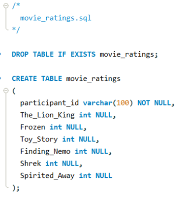

#### Load Data from CSV:

Data is loaded from a CSV file using LOAD DATA INFILE. The script handles missing values (-1) by converting them to NULL.

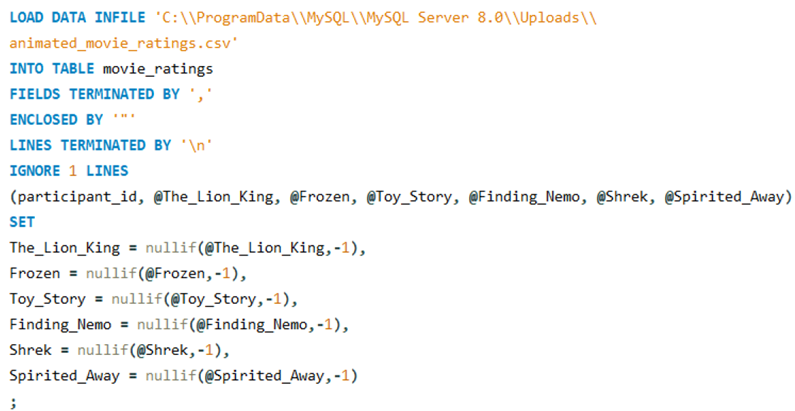

#### Data Query:

Data Query to display the data and the count of the total entries.

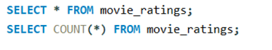

# Loading the information from the SQL database into an R dataframe

#### Installing and Loading Required Packages

```r
if (!requireNamespace("DBI", quietly = TRUE)) install.packages("DBI")
if (!requireNamespace("RMariaDB", quietly = TRUE)) install.packages("RMariaDB")
if (!requireNamespace("proxy", quietly = TRUE)) install.packages("proxy")
if (!requireNamespace("ggplot2", quietly = TRUE)) install.packages("ggplot2")
if (!requireNamespace("naniar", quietly = TRUE)) install.packages("naniar")

library(DBI)
library(RMariaDB)
library(proxy)
library(ggplot2)
library(naniar)
```

#### Connecting to the MySQL Database and Loading Data

Note - to use a password without having to share the password with people who are viewing your code, the password was stored in a .Renviron file in home directory (~) by adding as MYSQL_PWD=typethepassword.

```r
con <- dbConnect(
  RMariaDB::MariaDB(),
  user = 'root',
  password = Sys.getenv("MYSQL_PWD"),
  dbname = 'movies_rating',
  host = 'localhost',
  port = 3306
)

# Check if the connection is successful
if (!is.null(con)) {
  print("Connected successfully!")
} else {
  print("Connection failed.")
}
```

```
## [1] "Connected successfully!"
```

```r
# Load the data from the MySQL table into an R dataframe
ratings <- dbGetQuery(con, "SELECT * FROM movie_ratings")

# Close the database connection
dbDisconnect(con)
```

# Visualizing of results

#### Visualizing missing data pattern

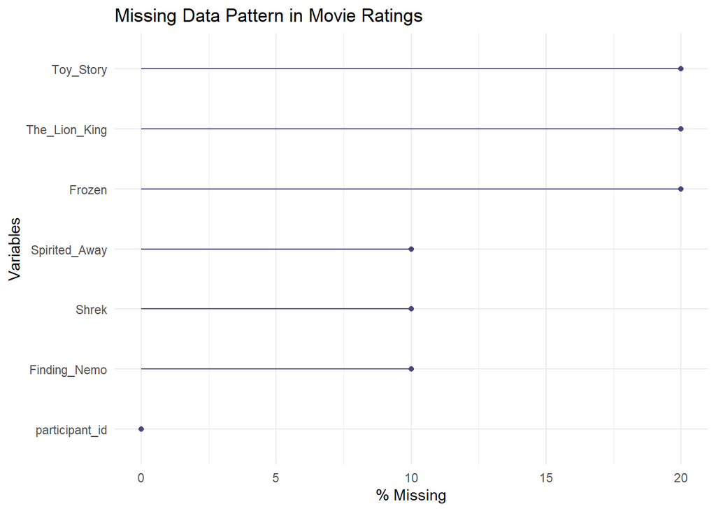

```r
ggplot_missing <- gg_miss_var(ratings, show_pct = TRUE) +
  labs(title = "Missing Data Pattern in Movie Ratings")
print(ggplot_missing)
```

#### Average ratings for movies

Calculate the average ratings for each movie, ignoring Null values. Convert to a data frame for visualization Plot the average ratings

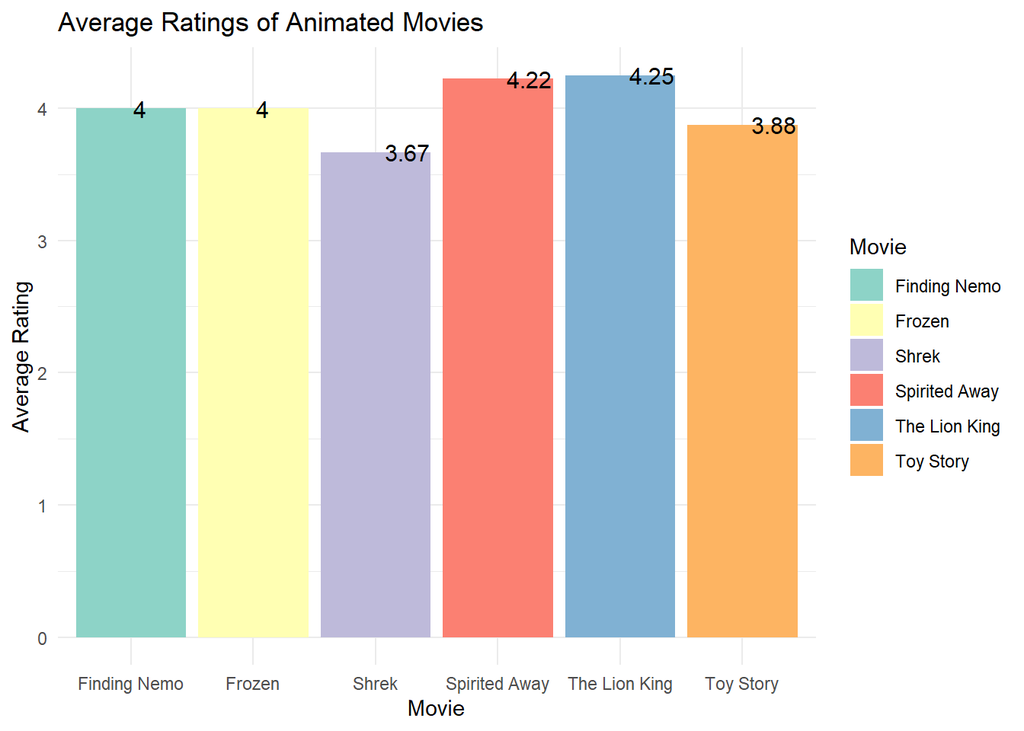

```r
average_ratings <- colMeans(ratings[,-1], na.rm = TRUE)

average_ratings_df <- data.frame(
  Movie = c("The Lion King", "Frozen", "Toy Story", "Finding Nemo", "Shrek", "Spirited Away"),
  Average_Rating = average_ratings
)

ggplot(average_ratings_df, aes(x = Average_Rating, y = Movie, fill = Movie)) +
  geom_bar(stat = "identity") +
  geom_text(aes(label = round(Average_Rating, 2)), vjust = 0.5, hjust = -0.2, size = 4) + # Data labels
  labs(title = "Average Ratings of Animated Movies", x = "Average Rating", y = "Movie") +
  scale_fill_brewer(palette = "Set3") + # Different colors for each movie
  theme_minimal() +
  coord_flip()
```

# Recommending movies

In the recommendation system, a matrix of user ratings (ratings_matrix) was used to predict movies that a user has not rated. First a similarity matrix (similarity_matrix) was computed using cosine similarity to measure how similar each user is to the others. The recommendation system calculates predicted ratings for movies that a user has not rated yet. Using the recommend_movies function, the system first identifies these unrated movies. It then computes a weighted score for each unrated movie based on the ratings from users with similar preferences. The result is a list of predicted scores, indicating how likely the user is to enjoy each movie they haven’t rated yet.

```r
ratings_matrix <- as.matrix(ratings[,-1])
rownames(ratings_matrix) <- ratings$participant_id

similarity_matrix <- as.matrix(simil(ratings_matrix, method = "cosine"))

recommend_movies <- function(user, ratings_matrix, similarity_matrix) {
  user_index <- which(rownames(ratings_matrix) == user)

  user_similarity <- similarity_matrix[user_index, -user_index]

  unrated_movies <- which(is.na(ratings_matrix[user_index, ]))

  # If no unrated movies, return a message
  if (length(unrated_movies) == 0) return("No movies to recommend")

  movie_scores <- unlist(sapply(unrated_movies, function(movie) {
    weighted_sum <- sum(user_similarity * ratings_matrix[-user_index, movie], na.rm = TRUE)
    sum_similarity <- sum(user_similarity, na.rm = TRUE)
    return(ifelse(sum_similarity == 0, 0, weighted_sum / sum_similarity))
  }))

  return(sort(movie_scores, decreasing = TRUE))
}
```

```r
# Get recommendations for "User1"
recommendations <- recommend_movies('1', ratings_matrix, similarity_matrix)
print(recommendations)
```

Shrek 3.669205

```r
# Get recommendations for "User2"
recommendations <- recommend_movies('2', ratings_matrix, similarity_matrix)
print(recommendations)
```

Frozen 3.552539

```r
# Get recommendations for "User3"
recommendations <- recommend_movies('3', ratings_matrix, similarity_matrix)
print(recommendations)
```

Spirited_Away 4.229354

```r
# Get recommendations for "User4"
recommendations <- recommend_movies('4', ratings_matrix, similarity_matrix)
print(recommendations)
```

The_Lion_King 3.773908

```r
# Get recommendations for "User5"
recommendations <- recommend_movies('5', ratings_matrix, similarity_matrix)
print(recommendations)
```

Toy_Story 3.451371

```r
# Get recommendations for "User6"
recommendations <- recommend_movies('6', ratings_matrix, similarity_matrix)
print(recommendations)
```

Frozen 3.548016

```r
# Get recommendations for "User7"
recommendations <- recommend_movies('7', ratings_matrix, similarity_matrix)
print(recommendations)
```

Toy_Story 3.445543

```r
# Get recommendations for "User8"
recommendations <- recommend_movies('8', ratings_matrix, similarity_matrix)
print(recommendations)
```

Finding_Nemo 4.00379

```r
# Get recommendations for "User9"
recommendations <- recommend_movies('9', ratings_matrix, similarity_matrix)
print(recommendations)
```

[1] “No movies to recommend”

```r
# Get recommendations for "User10"
recommendations <- recommend_movies('10', ratings_matrix, similarity_matrix)
print(recommendations)
```

The_Lion_King 3.779845